# Predict the 2018 US Senate Midterm Elections

Albert Kuo

# Motivation

As part of a [homework assignment](https://jhu-advdatasci.github.io/2018/homeworks/712-hw1-assignment.html) for my data science class (JHU 140.712 Advanced Data Science), we predicted the Senate results in each state based on US opinion polling data (and any other sources of data). Three competitions for the class were held:

1. Predict the number of Republican senators. You may provide an interval. Smallest interval that includes the election day result wins.
2. Predict the republican-democrat (R-D) difference in each state. The predictions that minimize the residual sum of squares between predicted and observed differences wins.
3. Report a confidence interval for the R-D difference in each state. If the election day result falls outside your confidence interval in more than two states you are eliminated. For those surviving this cutoff, we will add up the size of all confidence intervals and sum. The smallest total length of confidence interval wins.

In this document, I summarize the steps I took to build my model and my results.

# Data

I downloaded or scraped data from:

1. [RealClear Politics](https://www.realclearpolitics.com/epolls/2018/senate/2018_elections_senate_map.html) as well as their historical polling data for [2012](https://www.realclearpolitics.com/epolls/2012/senate/2012_elections_senate_map.html), [2014](https://www.realclearpolitics.com/epolls/2014/senate/2014_elections_senate_map.html), and [2016](https://www.realclearpolitics.com/epolls/2016/senate/2016_elections_senate_map.html)
2. Summary table from FiveThirtyEight used in their Senate Model (data available in a [CSV](https://projects.fivethirtyeight.com/congress-model-2018/senate_seat_forecast.csv) format)
3. Pollster ratings from FiveThirtyEight’s [github](https://github.com/fivethirtyeight/data/tree/master/pollster-ratings)

# Analysis

I adjusted for three effects in a Bayesian model:

1. **Pollster effect**. Take into account both the pollster’s reputation and their historical bias. The specific steps I took to adjust for the pollster effect are:
- Eliminate polls banned by 538. I was unable to find any in the data, which is good.
- Adjust numbers with mean-reverted bias, which represents a pollster’s bias (for Democrat or Republican candidates). For polls that I couldn’t match to the 538 pollster ratings, I did not adjust their reported differences. This adjustment created very minimal changes in the predictions, likely because most pollsters did not have significant biases.
- Weight using 538 rating. I converted the letter grade 538 gave to each poll, representative of their reputability, to a numeric value. For pollsters that I couldn’t match to 538’s pollster database, I assigned them a letter grade of “C”. This is more or less an arbitrary assignment, but I took into consideration the assumption that reputable polls are likely to be found in the database and balanced that against the possibility that the poll was in fact in the database, but I failed to match it.
2. **Time effect/recency**. Polls closer to the election date are considered to be more accurate and are thus weighted more heavily.
3. **Sample size**. The larger the sample size of the poll, the more confident its estimate is. This was naturally implemented through the Bayesian model. The main idea is that I set a (weakly informative) prior on the proportion voting Democrat and the proportion voting Republican. Iteratively, with every poll, I then update the prior distributions to get the posterior distributions. Then I use the posterior mean as the adjusted estimator.

Of the three, it turns out that only the time effect had any significant impact on the predictions over the naive model (where I use a simple mean of the polls as the prediction).

# Results

Below are plots of my predictions for the difference between Republican and Democrat votes for 2012, 2014, and 2016 along with the true election results. The blue circles are the adjusted estimators (with 95% credible intervals), the gray circles are the unadjusted naive estimators, and the colored diamonds are the true election results. Note that my intervals do a poor job of capturing the true result in many cases. I will account for this when submitting my result in Competition 3.

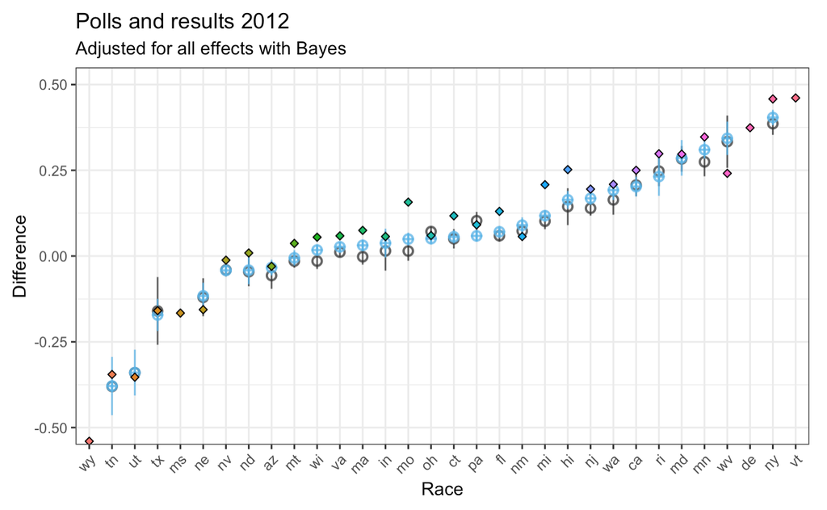

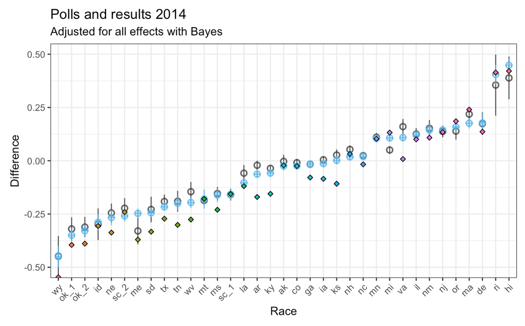

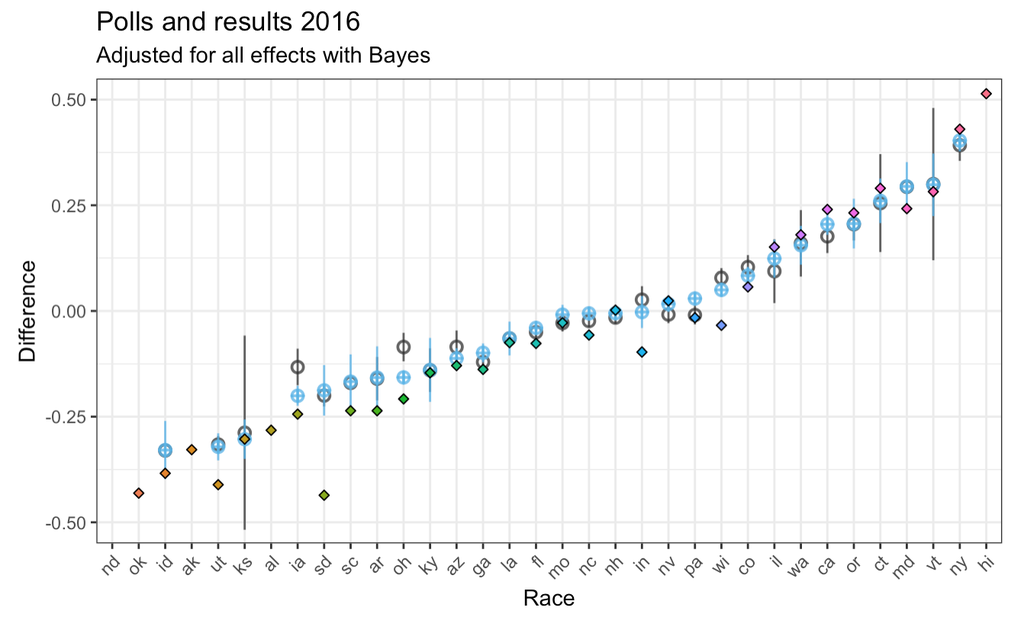

Below is a plot of my predictions for the 2018 election. Again, the blue circles are the adjusted estimators (with 95% credible intervals) and the gray circles are the unadjusted naive estimators. Since I don’t have the true election results, I use RealClear Politics’ average (RCP average) to plot the colored diamonds as a sanity check.

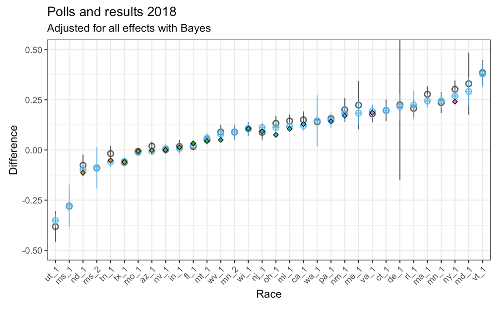

## Competition 1

*Predict the number of Republican senators. You may provide an interval. Smallest interval that includes the election day result wins.*

- For states without polls (as of 11/3), I referenced RealClear Politics’ predictions. Hawaii is predicted to be Democrat, Nebraska is predicted to be Republican, and Wyoming is predicted to be Republican. This is also equivalent to using their historical results to estimate their difference.
- Historically, the adjusted estimators have done a very good job of predicting the race outcome. If I use the Bayesian adjusted estimators, 2 races in 2012, 1 race in 2014, and 3 races in 2016 were called incorrectly (ignoring races without polls). Considering the fact that everyone in the class is going to give very similar predictions, this means that in order to win the competition, I need to give a very narrow interval (if any at all).
- With the adjusted estimators, I estimated 10 Republican wins in the races (as of 11/3, subject to change with new polls). The unadjusted estimators (poll averages), by comparison, also estimated 10 Republican wins. Therefore, it’s even more likely that everyone will give very similar/the same predictions, so I will not be giving an interval for my prediction. There are 42 uncontested Republican senators, so in total, I predict that there will be 52 Republican senators. As a sanity check, in comparison, 538 predicts that there will be 51 Republican senators.

*Update: The election outcome was 53 Republican senators. Since my interval did not contain 53, I was eliminated from the competition.*

## Competition 2

*Predict the republican-democrat (R-D) difference in each state. The predictions that minimize the residual sum of squares between predicted and observed differences wins.*

- The differences for states with polls were predicted using the Bayesian adjusted estimators described above.
- For states without polls (Hawaii, Nebraska, and Wyoming), I use historical data by taking the weighted average of previous estimators and the actual outcome. Results in more recent elections are weighted more heavily.

*Update: I won this competition!*

## Competition 3

*Report a confidence interval for the R-D difference in each state. If the election day result falls outside your confidence interval in more than two states you are eliminated. For those surviving this cutoff, we will add up the size of all confidence intervals and sum. The smallest total length of confidence interval wins.*

There is still bias that is unaccounted for, as is clearly evident in the 2012 and 2014 elections, where the credible intervals do a very poor job of covering the true election outcome. This implies that my confidence (credible) intervals should be determined not just by the sample size, but also the biases in the polling data. Since I couldn’t completely resolve the bias with the pollster effect or the time effect, the apparent bias may be a result of sampling bias (the samples polled do not reflect the actual voter population), which is very difficult to eliminate. Instead, to address this problem, I proposed the following simple solution:

1. Let the bias be the distance between the true election outcome and the nearest bound of the credible interval of the Bayesian adjusted estimator. If the true election outcome is contained in the credible interval, then the bias is 0. Consider the bias to be a random variable. I can get the empirical distribution of the bias and calculate the 90th quantile (since we can only miss 2/17 safe races = 12% of safe races). I will call this the bias adjustment factor.
2. I add the bias adjustment factor to the lower and upper bounds of the credible intervals. As long as the samples collected in the polls in 2018 aren’t more biased than what we’ve seen in previous years (i.e. follow the same distribution), these adjusted confidence intervals should do a decent job of covering the outcome. For the three states without polling data, it’s likely that my estimate is not very accurate at all, so I added and subtracted 2*bias_adj_factor (arbitrary multiplicative factor of 2) to get their confidence intervals.

*Update: I placed third in this competition. I failed to capture one state with my confidence intervals.*